# Working with VCF files

Mark Dunning

Last modified: 24 Jul 2016

# Introduction

In this session we:-

- Demonstrate how to call germline variants for a bam file containing aligned reads
- Explain what a *vcf* file is
- Loading a *vcf* file into IGV
- Interrogating vcf files using Bioconductor
- Intersect sets of calls

## Calling SNVs

We will use the [freebayes](https://github.com/ekg/freebayes#readme) genotype caller for convenience. The main reasons for choosing this were:-

- freely-available with an open-source licence
- easy to run and minimal command-line parameters to specify
- it is Bayesian; which we like
- gives reasonable results

`freebayes` is a command-line tool that you will need to run from the terminal. As with all command-line tools, we first need to make sure that we are located in the correct directory. Remember that we can *change directory* using the unix command `cd`.

`freebayes` is included in the *CRUK Docker*. However, we can make sure that `freebayes` is available by typing `freebayes` at the terminal. This will give a basic description, a version number, and information about how to cite the package (very important if you end-up using the tool to generate results for your paper). Adding the *parameter* `-h` will display more-detailed help about the tool and some examples of how to use it.

```
cd /home/participant/Course_Materials/Day2/
freebayes
freebayes -h
```

We are going to use `freebayes` to call SNVs on some *1000 genomes* samples. In order to make the SNV-calling run in a reasonable time, we are only considering reads aligned to chromosome 20 in this analysis. In the Appendix you will see the commands used to create the bam files.

The minimal requirements to run `freebayes` (and why it is appealing for this practical!) are a reference genome and a `.bam` file. The `-f` parameter is used to specify the location of a reference genome in `.fasta` format.

The reference file is in the folder `/home/participant/Course_Materials/ref_data`. However, rather than having the write the full *path* to the file, we can write the path relative to our current working directory (which is `/home/participant/Course_Materials/Day2`). When specifying the location of the files the `../` means to go one directory “*up*” from the current working directory.

*Please don’t run this next command*

```
freebayes -f ../ref_data/Homo_sapiens_assembly19.fasta ../data/hapmap/NA12878.chr20.bam
```

If you did run that command, you would quickly see that the screen gets filled with lots of text. These are the calls that `freebayes` is making being printed to the screen (the standard output for some unix commands). If you find yourself in this situation, a swift press of `CTRL + C` should stop the tool from running.

What we need to do is *direct the output* to a file. We can call the output file anything we like, but it is advisable to make the name relatable to the name of the input. If we are in the situation of calling genotypes on many samples, with many different callers, then we want to be able to identify the processing used on each sample.

Although it is not mandatory, we give the output file the extension `.vcf`. The `.vcf` format is a commonly-adopted standard for variant calls, which we will look into detail now.

```
freebayes -f ../ref_data/Homo_sapiens_assembly19.fasta ../data/hapmap/NA12878.chr20.bam > NA12878.chr20.freebayes.vcf
```

## Understanding the vcf format

The vcf format was initially developed by the [1000 Genomes Project](http://www.1000genomes.org/wiki/Analysis/vcf4.0), and ownership has been subsequently transferred to [Global Alliance for Genomics and Health Data Working group file format team](http://ga4gh.org/#/fileformats-team). The format can be used to represent information about all kinds of genomic variation. In this session we will just consider SNVs.

We don’t require any specialised software to look at the contents of a vcf file. They *can* be opened in a bog-standard text editor.For now, navigate to the folder and right-click on `NA12878.chr20.freebayes.vcf`. Select the option to open with `gedit` (a common text editor for Ubuntu).

In a similar vein to the `.bam` and `.sam` files we saw earlier, the `.vcf` files contains many lines of header information.

```
##fileformat=VCFv4.1
##fileDate=20160724
##source=freeBayes v1.0.2-33-gdbb6160
##reference=../ref_data/Homo_sapiens_assembly19.fasta
##contig=<ID=1,length=249250621>
##contig=<ID=2,length=243199373>
##contig=<ID=3,length=198022430>
##contig=<ID=4,length=191154276>
##contig=<ID=5,length=180915260>
##contig=<ID=6,length=171115067>
```

After many more lines of information, we finally get to the details of the actual calls themsevles. This part of the file is tab-delimited; with 10 columns for every call. The [vcf specification page](http://www.1000genomes.org/wiki/Analysis/vcf4.0) gives details of what should be contained in each column

- CHROM
- POS
- ID
- REF
- ALT
- QUAL
- FILTER
- INFO
- FORMAT
- NA12878

```
#CHROM  POS ID  REF ALT QUAL    FILTER  INFO    FORMAT  NA12878
20  61795   .   G   T   95.0616 .   AB=0.454545;ABP=3.20771;AC=1;AF=0.5;AN=2;AO=5;CIGAR=1X;DP=11;DPB=11;DPRA=0;EPP=3.44459;EPPR=4.45795;GTI=0;LEN=1;MEANALT=1;MQM=60;MQMR=60;NS=1;NUMALT=1;ODDS=21.8887;PAIRED=1;PAIREDR=1;PAO=0;PQA=0;PQR=0;PRO=0;QA=188;QR=245;RO=6;RPL=1;RPP=6.91895;RPPR=3.0103;RPR=4;RU…
20  63244   .   A   C   88.3208 .   AB=0.8;ABP=6.91895;AC=1;AF=0.5;AN=2;AO=4;CIGAR=1X;DP=5;DPB=5;DPRA=0;EPP=3.0103;EPPR=5.18177;GTI=0;LEN=1;MEANALT=1;MQM=60;MQMR=60;NS=1;NUMALT=1;ODDS=3.26311;PAIRED=1;PAIREDR=1;PAO=0;PQA=0;PQR=0;PRO=0;QA=149;QR=38;RO=1;RPL=4;RPP=11.6962;RPPR=5.18177;RPR=0;RUN=1;SAF=…
20  65900   .   G   A   44.2954 .   AB=0.3;ABP=6.48466;AC=1;AF=0.5;AN=2;AO=3;CIGAR=1X;DP=10;DPB=10;DPRA=0;EPP=3.73412;EPPR=3.32051;GTI=0;LEN=1;MEANALT=1;MQM=60;MQMR=60;NS=1;NUMALT=1;ODDS=10.1994;PAIRED=1;PAIREDR=1;PAO=0;PQA=0;PQR=0;PRO=0;QA=125;QR=250;RO=7;RPL=1;RPP=3.73412;RPPR=3.32051;RPR=2;RUN=1;…
20  66370   .   G   A   57.531  .   AB=0.4;ABP=3.87889;AC=1;AF=0.5;AN=2;AO=4;CIGAR=1X;DP=10;DPB=10;DPRA=0;EPP=11.6962;EPPR=4.45795;GTI=0;LEN=1;MEANALT=1;MQM=60;MQMR=60;NS=1;NUMALT=1;ODDS=13.247;PAIRED=1;PAIREDR=1;PAO=0;PQA=0;PQR=0;PRO=0;QA=150;QR=213;RO=6;RPL=3;RPP=5.18177;RPPR=4.45795;RPR=1;RUN=1;S…
```

The first seven columns should look consistent across different genotype callers. In this exercise we have not annotated against known variants, or applied any filtering, so the `ID` and `FILTER` columns are blank. In some `.vcf` files these columns might be populated with dbSNP IDs or flags such as `PASS` / `FAIL` respectively.

The contents of the `INFO` and `FORMAT` columns will depend on what variant caller has been used. The `INFO` column contains metrics and other information related to *each variant call* as a set of `KEY;VALUE` pairs. Each pair is separated by a `;` character.

The `INFO` for the first variant reads as:-

`AB=0.454545;ABP=3.20771;AC=1;AF=0.5;AN=2;AO=5;CIGAR=1X;DP=11;DPB=11;DPRA=0;EPP=3.44459;EPPR=4.45795;GTI=0;.......`

which we can interpret as:-

|  | Key | Value |
| --- | --- | --- |
| AB=0.454545 | AB | 0.454545 |
| ABP=3.20771 | ABP | 3.20771 |
| AC=1 | AC | 1 |
| AF=0.5 | AF | 0.5 |
| AN=2 | AN | 2 |
| AO=5 | AO | 5 |
| CIGAR=1X | CIGAR | 1X |
| DP=11 | DP | 11 |
| DPB=11 | DPB | 11 |
| DPRA=0 | DPRA | 0 |

The meaning of each `KEY` is given in the header for the `.vcf` file.

```
## ##INFO=<ID=AB,Number=A,Type=Float,Description="Allele balance at heterozygous sites: a number between 0 and 1 representing the ratio of reads showing the reference allele to all reads, considering only reads from individuals called as heterozygous">
```

```
## ##INFO=<ID=ABP,Number=A,Type=Float,Description="Allele balance probability at heterozygous sites: Phred-scaled upper-bounds estimate of the probability of observing the deviation between ABR and ABA given E(ABR/ABA) ~ 0.5, derived using Hoeffding's inequality">
```

```
## ##INFO=<ID=AC,Number=A,Type=Integer,Description="Total number of alternate alleles in called genotypes">
```

```
## ##INFO=<ID=AF,Number=A,Type=Float,Description="Estimated allele frequency in the range (0,1]">
```

```
## ##INFO=<ID=AN,Number=1,Type=Integer,Description="Total number of alleles in called genotypes">
```

```
## ##INFO=<ID=AO,Number=A,Type=Integer,Description="Alternate allele observations, with partial observations recorded fractionally">
```

```
## ##INFO=<ID=CIGAR,Number=A,Type=String,Description="The extended CIGAR representation of each alternate allele, with the exception that '=' is replaced by 'M' to ease VCF parsing.  Note that INDEL alleles do not have the first matched base (which is provided by default, per the spec) referred to b…
```

```
## ##INFO=<ID=DP,Number=1,Type=Integer,Description="Total read depth at the locus">
```

```
## ##INFO=<ID=DPB,Number=1,Type=Float,Description="Total read depth per bp at the locus; bases in reads overlapping / bases in haplotype">
```

```
## ##INFO=<ID=DPRA,Number=A,Type=Float,Description="Alternate allele depth ratio.  Ratio between depth in samples with each called alternate allele and those without.">
```

The final column in the file describes the calls for the sample `NA12878`, which was the only sample that we called variants on. In the sample column (`NA12878`) for the first variant we see the entry

(`0/1:11:11,5:6:245:5:188:-13.9693,0,-19.1141`).

These are values separated by a `:` character and they are interpreted in the same order as dictated by the `FORMAT` column which is `GT:DP:DPR:RO:QR:AO:QA:GL`

| Key | Value | Description |
| --- | --- | --- |
| GT | 0/1 | Genotype |
| DP | 11 | Read Depth |
| DPR | 11,5 | Number of observation for each allele |
| RO | 6 | Reference allele observation count |
| QR | 245 | Sum of quality of the reference observations |
| AO | 5 | Alternate allele observation count |
| QA | 188 | Sum of quality of the alternate observations |
| GL | -13.9693,0,-19.1141 | Genotype Likelihood, log10-scaled likelihoods of the data given the called genotype for each possible genotype generated from the reference and alternate alleles given the sample ploidy |

So for this particular variant, in the sample `NA12878` there is a genotype of `0\1` (heterozygous) and a depth of 11 etc.

To understand the vcf format better, we can use another mode of operation of `freebayes` which is to call genotypes on multiple samples simultaneously. We can also specify an exact region of the genome to call genotypes to speed-up the processing.

```
freebayes -f ../ref_data/Homo_sapiens_assembly19.fasta --region 20:500000-800000 ../data/hapmap/NA12878.chr20.bam ../data/hapmap/NA12873.chr20.bam ../data/hapmap/NA12874.chr20.bam > combined.chr20.subset.freebayes.vcf
```

```
#CHROM  POS ID  REF ALT QUAL    FILTER  INFO    FORMAT  NA12878 NA12873 NA12874
20  502620  .   G   A   124.93  .   AB=0;ABP=0;AC=2;AF=0.333333;AN=6;AO=5;CIGAR=1X;DP=24;DPB=24;DPRA=0.526316;EPP=3.44459;EPPR=5.8675;GTI=1;LEN=1;MEANALT=1;MQM=60;MQMR=60;NS=3;NUMALT=1;ODDS=1.91343;PAIRED=1;PAIREDR=1;PAO=0;PQA=0;PQR=0;PRO=0;QA=206;QR=587;RO=19;RPL=2;RPP=3.44459;RPPR=5.8675;RPR=3;RUN…
20  502793  .   G   A   508.485 .   AB=0;ABP=0;AC=2;AF=0.333333;AN=6;AO=18;CIGAR=1X;DP=36;DPB=36;DPRA=2;EPP=3.49285;EPPR=3.49285;GTI=0;LEN=1;MEANALT=1;MQM=60;MQMR=57;NS=3;NUMALT=1;ODDS=2.14415;PAIRED=1;PAIREDR=1;PAO=0;PQA=0;PQR=0;PRO=0;QA=659;QR=702;RO=18;RPL=10;RPP=3.49285;RPPR=3.0103;RPR=8;RUN=1;S…
20  502937  .   C   T   144.588 .   AB=0.5;ABP=3.0103;AC=2;AF=0.333333;AN=6;AO=7;CIGAR=1X;DP=27;DPB=27;DPRA=0.538462;EPP=3.32051;EPPR=3.44459;GTI=0;LEN=1;MEANALT=1;MQM=60;MQMR=60;NS=3;NUMALT=1;ODDS=5.35048;PAIRED=1;PAIREDR=1;PAO=0;PQA=0;PQR=0;PRO=0;QA=270;QR=750;RO=20;RPL=3;RPP=3.32051;RPPR=3.44459;…
20  504482  .   G   A   41.2659 .   AB=0;ABP=0;AC=2;AF=0.333333;AN=6;AO=3;CIGAR=1X;DP=7;DPB=7;DPRA=1.5;EPP=3.73412;EPPR=3.0103;GTI=1;LEN=1;MEANALT=1;MQM=60;MQMR=54;NS=3;NUMALT=1;ODDS=1.33886;PAIRED=1;PAIREDR=1;PAO=0;PQA=0;PQR=0;PRO=0;QA=112;QR=133;RO=4;RPL=3;RPP=9.52472;RPPR=5.18177;RPR=0;RUN=1;SAF=…
```

You should notice that we now have columns `NA12878`, `NA12873` and `NA12874` as we have called variants in three samples.

One easy way of being able to visualise the calls is to use the IGV browser. Before we do this however, we can do some extra processing to make it easier to process the files. This series of commands will compress and index the vcf files (similar to how bam files are indexed to produce a `.bai` file). IGV would probably cope fine with reading such relatively-small files, but it is good to get into the habit of processing our files in this manner.

```
bgzip -c combined.chr20.subset.freebayes.vcf > combined.chr20.subset.freebayes.vcf.gz
tabix -p  vcf combined.chr20.subset.freebayes.vcf.gz

bgzip -c NA12878.chr20.freebayes.vcf > NA12878.chr20.freebayes.vcf.gz
tabix -p vcf NA12878.chr20.freebayes.vcf.gz
```

After running these commands, you should see that the files `combined.chr20.subset.freebayes.vcf.gz`, `combined.chr20.subset.freebayes.vcf.gz.tbi`, `NA12878.chr20.freebayes.vcf.gz` and `NA12878.chr20.freebayes.vcf.gz.tbi` have been created in your working directory.

These files can be viewing in IGV and as usual we can zoom-in and scroll along the genome. Each `.vcf` introduces two tracks into the IGV data panel; the first gives information about the variant, and the second is for sample-specific information.

### Exercise

- Load IGV
- Select the files `NA12878.chr20.freebayes.vcf.gz` and `combined.chr20.subset.freebayes.vcf.gz` from the `File -> Open` menu
- Navigate to `chr20:500,900-505,630`
- Verify that the same information from the `.vcf` is shown in IGV
- What do the light and dark blue rectangles in the sample-specific tracks refer to?
- What SNPs are shared between the different samples?
  - are any unique to a particular sample?

To dig-into these files further, we will use tools within Bioconductor. Our goal will be to find calls that are in common between different samples, and what SNPs occur within coding regions. For completeness, we note that other command-line tools can be used to perform these operations (the [bedtools](http://bedtools.readthedocs.io/en/latest/) suite for example). However, we should be reasonably comfortable with R by now and the package we use interacts nicely with the `GenomicRanges` concepts we discussed yesterday.

## Importing into Bioconductor

### Working directory

*Session* -> *Set Working Directory* -> *Choose Directory*

```
/home/participant/Course_Materials/Day2/
```

### Template

```
/home/participant/Course_Materials/Day2/Session1-template.Rmd
```

### Multi-sample example

The `VariantAnnotation` package allows `.vcf` files to be imported. The `readVcf` function can be used and requires the file of a vcf file. You also need to specify a genome name. As we have seen already with other Bioconductor objects, typing the name of the object will print a summary to the screen. In the case of a “`CollapsedVCF`” object this is very detailed

```r
library(VariantAnnotation)
hapmap.calls <- readVcf("combined.chr20.subset.freebayes.vcf","hg19")
```

```r
hapmap.calls
```

The “header” information can be extracted using `header`. This will contain the definitions of all the per-genotype (`INFO`) and per-sample information stored in the file

```r
header(hapmap.calls)
info(header(hapmap.calls))
geno(header(hapmap.calls))
```

## `INFO`

As described above, the `INFO` column in a `.vcf` file gives per-variant metadata as a series of key-value pairs. We can interrogate these data using the `info` function, which returns a data-frame-like object. Consequently, we can use the `$` operator to select a particular column of interest.

The name of each row is derived from the genomic location and base-change for each variant. There are too many columns to go through in detail, so we will just describe a few that are likely to be common to different callers.

```r
info(hapmap.calls)
```

`NS` represents the number of samples with data. We would expect this to be 3 in all cases. However, as we are dealing with low-coverage data there are some sites where data could not be observed for all samples.

`DP` gives the depth observed at each position, which is given to us in the form of a vector. By looking at the distribtion of the depths, we see some variants with extremely low coverage. Later-on, we will see how we can develop filters to remove unreliable calls from our dataset. Variants with low depth would seem to be a good candidate for exclusion.

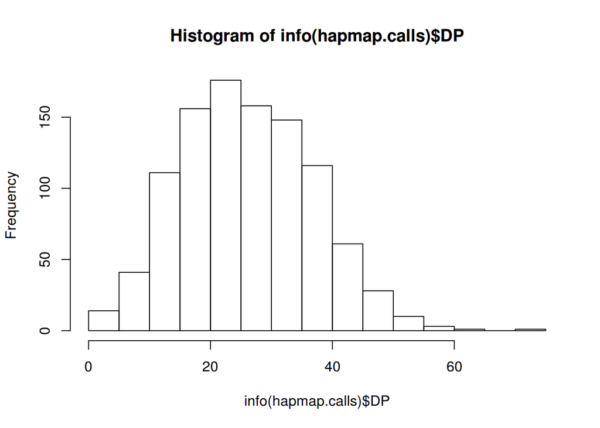

```r
hist(info(hapmap.calls)$DP)
```

If we take an arbitrary cut-off of 25, we could identify which variants have sufficient depth and then write the result to another `.vcf` file.

```r
enoughDepth <- which(info(hapmap.calls)$DP > 25)
writeVcf(hapmap.calls[enoughDepth], filename = "combined.chr20.subset.freebayes.highDepth.vcf")
```

## Accessing genotypes

The called genotypes can be accessed using the `geno` function. Recall that in the `.vcf` file, we have one column of genotype information for each sample, with each column consisting of `key:value` pairs. Using `geno` we can access all the values for a particular keys and be able to compare across samples.

The column names of the data frame returned by `geno` are the same as the `FORMAT` in the `.vcf` description. Thus we can use a `$` operator to access a particular set of values; `GT` in this case

```r
geno(hapmap.calls)
```

```
## List of length 10
## names(10): GT GQ GL DP DPR RO QR AO QA MIN_DP
```

```r
head(geno(hapmap.calls)$GT)
```

```
##               NA12878 NA12873 NA12874
## 20:502620_G/A "0/0"   "1/1"   "0/0"
## 20:502793_G/A "0/0"   "0/0"   "1/1"
## 20:502937_C/T "0/1"   "0/1"   "0/0"
## 20:504482_G/A "0/0"   "0/0"   "1/1"
## 20:504789_C/T "1/1"   "0/1"   "0/0"
## 20:505120_C/T "0/0"   "0/1"   "0/0"
```

The output allows us to compare the genotype for a particular variant across all samples; which we could not easily do from the `.vcf`.

Usually each entry is `0/0` for a homozygous reference, `0/1` for a heterozygous call and `1/1` for a homozyous alternate allele. An entry of `.` indicates a position where no call could be made due to insufficient data. Moreover, we can also find `0/2` and `1/2` in rare cases where a second alternative allele was found.

With `table` we can tabulate the calls between one sample and another

```r
table(geno(hapmap.calls)$GT[,1])
```

```
##
##   . 0/0 0/1 1/1 1/2
##  28 500 220 273   3
```

```r
table(geno(hapmap.calls)$GT[,2])
```

```
##
##   . 0/0 0/1 0/2 1/1 1/2
##  12 399 446   2 161   4
```

```r
table(geno(hapmap.calls)$GT[,1], geno(hapmap.calls)$GT[,2])
```

```
##
##         . 0/0 0/1 0/2 1/1 1/2
##   .     3   6  11   0   8   0
##   0/0   2 231 249   1  16   1
##   0/1   2 110  75   0  33   0
##   1/1   5  52 110   0 104   2
##   1/2   0   0   1   1   0   1
```

### Exercise

- Find the variants that are called Heterozygous in all three samples
- Create a new `.vcf` file containing just these heterozygous variants

## Variant locations

In this section we will see how we can overlap the calls we have made with other genomic features, such as the pre-built gene models that we saw yesterday.

For this section, we are going to use all calls made on chromosome 20 for a single sample; `NA12878`. As we discovered yesterday, it can be problematic trying to perform overlaps when the chromosome naming convention is not consistent between files. Consequently, we are going to rename our variants to the `UCSC` style from the start.

```r
NA12878.calls <- readVcf("NA12878.chr20.freebayes.vcf","hg19")
seqlevelsStyle(NA12878.calls) <- "UCSC"
NA12878.calls <- keepSeqlevels(NA12878.calls, "chr20")
```

The `rowRanges` function will retrieve the positions of our variants as a familiar `GRanges` object. Along with the usual positional information, we also get extra “metadata” (`mcols`) about the base-change, a quality-score from `freebayes` and a placeholder for a filter (which has not been applied in this case).

```r
NA12878.calls.ranges <- rowRanges(NA12878.calls)
```

```r
NA12878.calls.ranges
```

[output not shown]

## Overlapping with genes

We saw yesterday how to retrieve the coordinates for all genes in a given organism and genome-build. For this example, we can again use the package `TxDb.Hsapiens.UCSC.hg19.knownGene`

```r
library(TxDb.Hsapiens.UCSC.hg19.knownGene)
txdb <- TxDb.Hsapiens.UCSC.hg19.knownGene
```

### Exercise

Find and count all `NA12878` variants that have been called within the gene “PRND”

- this gene has an Entrez ID of “23627”
  - recall the `exonsBy` and `%over%`, `countOverlaps` functions from yesterday….
- check your answer in IGV

We are not just restricted to overlapping with these pre-defined gene models. If we have a set of generic regions in `.bed` or similar format we can import as a `GRanges` object using the `rtracklayer` package and call the `countOverlaps` and `%over%` functions as usual.

```r
library(rtracklayer)
regions <- import("regions.of.interest.bed")
regions
NA12878.calls.ranges[NA12878.calls.ranges %over% regions]
countOverlaps(regions, NA12878.calls.ranges)
```

## More-automated location of variants

With a bit of scripting it would be possible to *loop* through a series of gene locations and identify which gene each variant is located within. However, there is a convenience function `locateVariants` that will do the hard work for us. It has flexibility to allow us to search for variants within coding, intergenic or other regions. For example, adding the `CodingVariants()`argument tells the function to look for variants within coding sequences. You can see the help for `locateVariants` (`?locateVariants`) for information on the various options.

As this function runs you should see some message sbout `select()' returned many:1 mapping between keys and columns`. This is because some variants might be located within multiple transcripts for the same gene.

```r
locs <- locateVariants(NA12878.calls.ranges, txdb, CodingVariants())
locs
```

[output not shown]

This annotation step has put *Entrez IDs* into the `locs` object, which is great if we want overlap with transcript databases. However, we are more likely to be familiar with gene symbols. We can do a look-up using the `org.Hs.eg.db` package that we saw yesterday and add the identifiers we retrieve to the table.

```r
library(org.Hs.eg.db)
symbol <- select(org.Hs.eg.db, keys=mcols(locs)$GENEID, keytype = "ENTREZID", columns="SYMBOL")
head(symbol)
```

```
##   ENTREZID  SYMBOL
## 1   245938 DEFB125
## 2    81623 DEFB126
## 3   245939 DEFB128
## 4   400830 DEFB132
## 5    85364  ZCCHC3
## 6    57761   TRIB3
```

```r
mcols(locs)$SYMBOL <- symbol[,2]
locs
```

```
## GRanges object with 1133 ranges and 10 metadata columns:
##        seqnames               ranges strand | LOCATION  LOCSTART    LOCEND
##           <Rle>            <IRanges>  <Rle> | <factor> <integer> <integer>
##      1    chr20     [ 76962,  76962]      + |   coding       375       375
##      2    chr20     [126310, 126316]      + |   coding       313       319
##      3    chr20     [168728, 168728]      - |   coding        81        81
##      4    chr20     [238435, 238442]      + |   coding        16        23
##      5    chr20     [279185, 279185]      + |   coding       958       958
##    ...      ...                  ...    ... .      ...       ...       ...
##   1129    chr20 [62597666, 62597666]      - |   coding       862       862
##   1130    chr20 [62597694, 62597694]      - |   coding       834       834
##   1131    chr20 [62598815, 62598815]      - |   coding       183       183
##   1132    chr20 [62608677, 62608677]      - |   coding       174       174
##   1133    chr20 [62737568, 62737568]      - |   coding       617       617
##          QUERYID        TXID         CDSID      GENEID       PRECEDEID
```

[output cut: 27 more lines]

If we want, we can locate all the variants with respect to the nearest feature (in the case of intergenic variants).

```r
all.locs <- locateVariants(NA12878.calls.ranges, txdb, AllVariants())
```

```r
all.locs
table(all.locs$LOCATION)
```

[output not shown]

```
##
## spliceSite     intron    fiveUTR   threeUTR     coding intergenic
##         52      93846        274       1790       1133      41861
##   promoter
##       4209
```

## Predicting Amino acid changes

```r
library(BSgenome.Hsapiens.UCSC.hg19)
hg19 <-BSgenome.Hsapiens.UCSC.hg19
getSeq(hg19, GRanges("chr20", IRanges(76960,76962)))
```

```
##   A DNAStringSet instance of length 1
##     width seq
## [1]     3 TCT
```

```r
translate(getSeq(hg19, GRanges("chr20", IRanges(76960,76962))))
```

```
##   A AAStringSet instance of length 1
##     width seq
## [1]     1 S
```

There is a function, `predictCoding` that will do all the predictions for us. In order to make use of this function, we need to have loaded a pre-built genome in `Biostrings` format. There are many such packages listed on the bioconductor web page. The one we need is `BSgenome.Hsapiens.UCSC.hg19`

```r
coding.pred <- predictCoding(NA12878.calls, txdb, seqSource=Hsapiens)
```

```r
coding.pred
table(coding.pred $CONSEQUENCE)
```

[output not shown]

```
##
##    frameshift      nonsense nonsynonymous    synonymous
##             2             2           575           554
```

## Summary

- We have used a respected genotype caller `freebayes` to call SNVs from a set of healthy individuals
  - there are many paramters that can be tweaked that we haven’t described here
- The `.vcf` format contains a rich description of the called variants
- Bioconducor tools can be used to import and parse `.vcf` files
- We can use `GenomicRanges` to overlap our calls with other genomic features of interest
- Production-level manipulation of `.vcf` would probably involve other non-R tools
  - [bedtools](http://bedtools.readthedocs.io/en/latest/)
  - [vcftools](https://vcftools.github.io/index.html)

## EXTRA:- Producing an output table

To recap, we have information in the following tables

- `NA12878.calls.ranges` which has locations, details of the base-changes and a quality-score for each variant
- A table of variants which occur in the coding region of genes; `locs`
- meta information about the quality of each call; `info(NA12878.calls)`

```r
locs.df <- as.data.frame(locs)
dim(locs.df)
```

```
## [1] 1133   15
```

```r
meta <- mcols(NA12878.calls.ranges)
head(meta)
```

```
## DataFrame with 6 rows and 5 columns
##   paramRangeID            REF                ALT      QUAL      FILTER
##       <factor> <DNAStringSet> <DNAStringSetList> <numeric> <character>
## 1           NA              G                  T   95.0616           .
## 2           NA              A                  C   88.3208           .
## 3           NA              G                  A   44.2954           .
## 4           NA              G                  A   57.5310           .
## 5           NA             TT       TTGGTATCTAGT   44.2540           .
## 6           NA              T                  C  186.8270           .
```

```r
dim(meta)
```

```
## [1] 74702     5
```

```r
info.df <- info(NA12878.calls)
dim(info.df)
```

```
## [1] 74702    44
```

As not all variants are inside coding regions, the number of rows in `locs` is not the same as the total number of variants. However, the column `locs$QUERYID` gives an index that we can use to look-up the relevant rows in the complete set of calls. Below we show how the extract data fror the first five coding variants.

```r
locs.df[1:5,]
```

```
##   seqnames  start    end width strand LOCATION LOCSTART LOCEND QUERYID
## 1    chr20  76962  76962     1      +   coding      375    375      11
## 2    chr20 126310 126316     7      +   coding      313    319      51
## 3    chr20 168728 168728     1      -   coding       81     81     165
## 4    chr20 238435 238442     8      +   coding       16     23     269
## 5    chr20 279185 279185     1      +   coding      958    958     304
##    TXID  CDSID GENEID PRECEDEID FOLLOWID  SYMBOL
## 1 70477 206101 245938                    DEFB125
## 2 70478 206103  81623                    DEFB126
## 3 71525 209098 245939                    DEFB128
## 4 70481 206108 400830                    DEFB132
## 5 70482 206110  85364                     ZCCHC3
```

```r
locs.df$QUERYID[1:5]
```

```
## [1]  11  51 165 269 304
```

```r
NA12878.calls.ranges[locs.df$QUERYID[1:5],]
```

```
## GRanges object with 5 ranges and 5 metadata columns:
##                           seqnames           ranges strand | paramRangeID
##                              <Rle>        <IRanges>  <Rle> |     <factor>
##              20:76962_T/C    chr20 [ 76962,  76962]      * |         <NA>
##   20:126310_ACCCCCG/ACCCG    chr20 [126310, 126316]      * |         <NA>
##             20:168728_T/A    chr20 [168728, 168728]      * |         <NA>
##     20:238435_CTGGTCTT/CT    chr20 [238435, 238442]      * |         <NA>
##             20:279185_C/T    chr20 [279185, 279185]      * |         <NA>
##                                      REF                ALT      QUAL
##                           <DNAStringSet> <DNAStringSetList> <numeric>
##              20:76962_T/C              T                  C  112.0310
##   20:126310_ACCCCCG/ACCCG        ACCCCCG              ACCCG   15.1176
##             20:168728_T/A              T                  A  237.0390
##     20:238435_CTGGTCTT/CT       CTGGTCTT                 CT   62.9073
##             20:279185_C/T              C                  T   39.4505
##                                FILTER
##                           <character>
##              20:76962_T/C           .
##   20:126310_ACCCCCG/ACCCG           .
##             20:168728_T/A           .
##     20:238435_CTGGTCTT/CT           .
##             20:279185_C/T           .
##   -------
##   seqinfo: 1 sequence from hg19 genome
```

### Exercise

Construct a data frame containing:-

- The `locs.df` data frame with details of all the coding variants
- The metadata from the ranges object in the `meta` data frame
- `INFO` columns `DP`, `NS`, `RO` and `AO` from `info.df`
  - or any other columns you think might be of interest
- Write this data frame to a tab-delimited text file

```
##   seqnames  start    end width strand LOCATION LOCSTART LOCEND QUERYID
## 1    chr20  76962  76962     1      +   coding      375    375      11
## 2    chr20 126310 126316     7      +   coding      313    319      51
## 3    chr20 168728 168728     1      -   coding       81     81     165
## 4    chr20 238435 238442     8      +   coding       16     23     269
## 5    chr20 279185 279185     1      +   coding      958    958     304
## 6    chr20 371972 371972     1      +   coding      333    333     454
##    TXID  CDSID GENEID PRECEDEID FOLLOWID  SYMBOL paramRangeID      REF
## 1 70477 206101 245938                    DEFB125         <NA>        T
## 2 70478 206103  81623                    DEFB126         <NA>  ACCCCCG
## 3 71525 209098 245939                    DEFB128         <NA>        T
## 4 70481 206108 400830                    DEFB132         <NA> CTGGTCTT
## 5 70482 206110  85364                     ZCCHC3         <NA>        C
## 6 70485 206116  57761                      TRIB3         <NA>        T
##     ALT     QUAL FILTER DP NS RO AO
## 1     C 112.0310      .  4  1  0  4
## 2 ACCCG  15.1176      .  4  1  2  2
## 3     A 237.0390      .  7  1  0  7
## 4    CT  62.9073      .  3  1  0  3
## 5     T  39.4505      .  5  1  2  3
## 6     C  11.0642      .  3  1  1  2
```

# Appendix

## Files used in session

Commands used to generate bam files for genotype calling

- First, get a copy of the reference genome from the 1000 genomes FTP site

```
wget ftp://ftp.1000genomes.ebi.ac.uk/vol1/ftp/technical/reference/Homo_sapiens_assembly19.fasta.gz -P ../ref_data/
gunzip ../ref_data/Homo_sapiens_assembly19.fasta.gz
```

```
wget ftp://ftp.ncbi.nlm.nih.gov/1000genomes/ftp/phase3/data/NA12878/alignment/NA12878.chrom20.ILLUMINA.bwa.CEU.low_coverage.20121211.bam -O NA12878.chr20.bam
samtools index NA12878.chr20.bam

wget ftp://ftp.ncbi.nlm.nih.gov/1000genomes/ftp/phase3/data/NA12874/alignment/NA12874.chrom20.ILLUMINA.bwa.CEU.low_coverage.20130415.bam -O NA12874.chr20.bam
samtools index NA12874.chr20.bam


wget ftp://ftp.ncbi.nlm.nih.gov/1000genomes/ftp/phase3/data/NA12873/alignment/NA12873.chrom20.ILLUMINA.bwa.CEU.low_coverage.20130415.bam -O NA12873.chr20.bam
samtools index NA12873.chr20.bam

wget http://www.broadinstitute.org/ftp/pub/seq/references/Homo_sapiens_assembly19.fasta
wget http://www.broadinstitute.org/ftp/pub/seq/references/Homo_sapiens_assembly19.fasta.fai
wget http://www.broadinstitute.org/ftp/pub/seq/references/Homo_sapiens_assembly19.dict
```

# References

- [freebayes tutorial](http://clavius.bc.edu/~erik/CSHL-advanced-sequencing/freebayes-tutorial.html)
- [freebayes tutorial 2](https://libraries.io/github/benjaypunto/freebayes)
- [vcf files tutorial](https://faculty.washington.edu/browning/beagle/intro-to-vcf.html)
- [bedtools tutorial](http://quinlanlab.org/tutorials/bedtools/bedtools.html)